# Intercrop Summary

### means of oat and pea grain yield for each environment

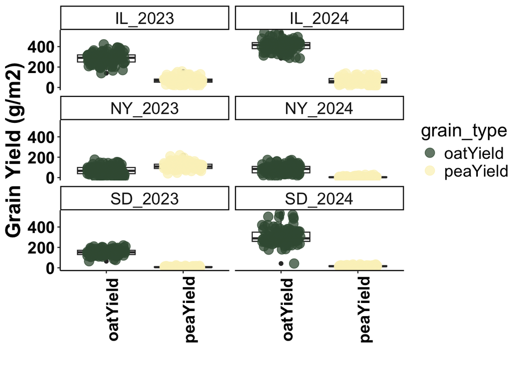

```r
grainWgt2 %>%
  pivot_longer(oatYield:peaYield,
               names_to = "grain_type", values_to = "grain_g") %>%
  mutate(grain_type = str_replace(grain_type, "_yield", "")) %>%
  mutate(log_grain_g = log(grain_g)) %>%

  # Create a new column that combines location and year
  mutate(location_year = paste(location, studyYear, sep = "_")) %>%

  ggplot(aes(grain_type, grain_g)) +
  geom_boxplot() +
  geom_jitter(aes(grain_type, grain_g, color = grain_type),
              width = 0.25, size = 4, alpha = 0.75) +

  xlab("") +
  ylab("Grain Yield (g/m2)") +
  scale_color_manual(values = hcl.colors(3, palette = "Fall")) +
  #scale_color_brewer(palette = "Dark2") +
  theme_classic() +
  theme(axis.text.x = element_text(angle = 90, hjust = 0.5)) +
  theme(axis.text = element_text(size = 20), axis.title = element_text(size = 20, face = "bold")) +
  theme(axis.text.x = element_text(face = "bold", color = "black", size = 16)) +
  theme(axis.text.y = element_text(face = "bold", color = "black", size = 16)) +

  theme(strip.text = element_text(size = 16, face = "plain"),
        legend.text = element_text(size = 16),
        legend.title = element_text(size = 18, face = "plain")) +   # Adjust the subtitles and ledgend font size

  # Facet by both location and year
  facet_wrap(~location_year, nrow = 3, ncol = 2)
```

```r
# means for each environment
year_list <- c("2023", "2024")
location_list <- c("NY", "IL", "SD")

# just compare means of intercrop plots

for (i in year_list){
  for (j in location_list) {
  means <- grainWgt2 %>%
  filter(studyYear == i, location == j) %>%
  summarize(
    mean_oatYield = mean(oatYield, na.rm = TRUE),
    mean_peaYield = mean(peaYield, na.rm = TRUE),
    mean_totalYield = mean(total_grain, na.rm = TRUE)
  )
  print(paste("Year:", i, "Location:", j))
  print(means)
  }
}
```

```
## [1] "Year: 2023 Location: NY"
##   mean_oatYield mean_peaYield mean_totalYield
## 1      68.91307      115.1812        184.0943
## [1] "Year: 2023 Location: IL"
##   mean_oatYield mean_peaYield mean_totalYield
## 1      285.5225      69.97824        355.5008
## [1] "Year: 2023 Location: SD"
##   mean_oatYield mean_peaYield mean_totalYield
## 1      152.2822       7.88966        160.1719
## [1] "Year: 2024 Location: NY"
##   mean_oatYield mean_peaYield mean_totalYield
## 1         82.92          5.66           88.58
## [1] "Year: 2024 Location: IL"
##   mean_oatYield mean_peaYield mean_totalYield
## 1      409.1726      66.49603        475.6686
## [1] "Year: 2024 Location: SD"
##   mean_oatYield mean_peaYield mean_totalYield
## 1        307.21         16.03          323.24
```

Create matrix for response and factors

```r
yTraits <- as.matrix(dplyr::select(grainWgt2, contains("Yield")))# pulls oat yield and pea yield ; taking factors with yield in them from grain weight table and making them a matrix # could have as many y variables in the matrix as you want, will run each on their own but no limit to what matrix holds
#factors into matrices
incLocations <- model.matrix(~ -1 + location, grainWgt2) # 0,1 for if plots existed in given location or not; going into grain weight table, pulling out location data, and turns it into 0,1 somehow
incBlocks <- model.matrix(~ -1 + blockNumberF, grainWgt2)
incOatAcc <- model.matrix(~ -1 + germplasmName, grainWgt2)
incPeaAcc <- model.matrix(~ -1 + peaAcc, grainWgt2)
incYear <- model.matrix(~ -1 + studyYear, grainWgt2) #year factor
```

Create K matrix

```r
#  use K = Z %*% GRM %*% t(Z),  Z is incidence matrix
K2 = incOatAcc %*% GRM3 %*% t(incOatAcc)
```

list of factor matrices

```r
ETA <- list(list(X=incLocations, model="FIXED"),
            list(X=incBlocks, model="BRR"),
            list(X=incPeaAcc, model="BRR"),
            list(X=incYear, model="BRR"),
            list(K = K2, model="RKHS"))

# the order of these is critical: nothing is labeled in matrices, so we need to know it's position to pull the right info out of results (through it's number rather than a name)
```

BGLR Model

```r
# this will take a few seconds to run, ?how doe we evaluate the best number of nIter and burnIn?
# will set.seed make this reproducible?

bglr_model <- BGLR::Multitrait(yTraits, ETA, intercept=TRUE,
                         resCov=list(df0=4,S0=NULL,type="UN"),
                         R2=0.5,
                         nIter=10000, burnIn=2000,
                         thin=10, saveAt="",verbose=FALSE)
```

```
##             oatYield   peaYield
## oatYield 11492.52972  -72.86776
## peaYield   -72.86776 1322.55855
```

```
##             oatYield   peaYield
## oatYield 12018.51865  -76.20277
## peaYield   -76.20277 1383.08927
```

```
##            oatYield  peaYield
## oatYield 22027.9957 -139.6673
## peaYield  -139.6673 2534.9784
```

```
##            oatYield  peaYield
## oatYield 6861.52745 -43.50514
## peaYield  -43.50514 789.62352
```

```
##            oatYield  peaYield
## oatYield 64245.4269 -407.3446
## peaYield  -407.3446 7393.3538
```

BGLR Results

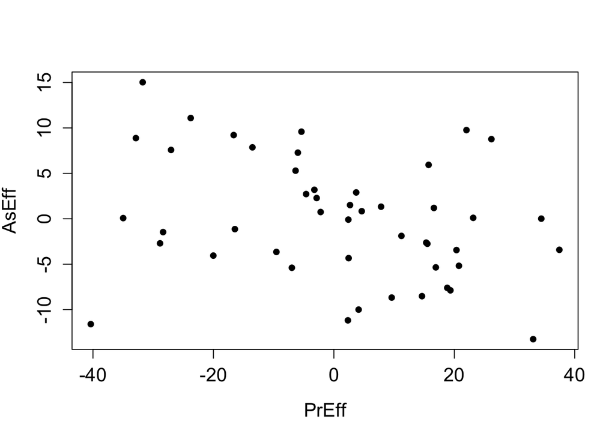

```r
oatEff <- bglr_model$ETA[[5]]$beta # BLUP for accessions
#oatEff

plot(oatEff, xlab="PrEff", ylab="AsEff",
     cex.lab=1.3, cex.axis=1.3, pch=16)
```

```r
# add oat names to effect results
colnames(oatEff) <- c("PrEff", "AsEff")
rownames(oatEff) <- c(accessions_47$germplasmName)
oatEff
```

```
##                   PrEff        AsEff
## A10            3.710579   2.89673010
## A11           15.523255  -2.75055148
## A25          -16.638504   9.21117398
## BAKER         -2.199767   0.74215813
## BUCKSKIN       2.330727 -11.18282322
## COLT          -2.858378   2.28225366
## CORRAL        19.355047  -7.87843208
## DEON         -13.520135   7.86068556
## ESKER         15.731182   5.93162184
## EXCEL         33.096256 -13.25419482
## GOLIATH        4.109478 -10.00216823
## GOPHER        -4.605726   2.71776100
## HAYDEN        -5.979108   7.27607137
## HORSEPOWER    14.634385  -8.52110582
## IL15-5752     37.444004  -3.41856809
## IL17-1253     -6.975598  -5.39349546
## IL17-1704     -9.541503  -3.65236683
## IL17-5238     11.220557  -1.88754175
## IL17-733X     18.828478  -7.60590311
## LEGGETT       -6.359591   5.29268693
## MN18015X_004  20.764841  -5.17832282
## MN18038X_008 -27.035467   7.57540112
## NATTY          2.451372  -4.33477725
## ND161488       2.407225  -0.09542851
## ND170307     -32.878697   8.87855026
## ND170376     -34.983568   0.07352824
## NEWBURG        2.685316   1.50703455
## OGLE          20.361110  -3.44457008
## OT2130        16.611746   1.18933961
## OT3120        26.161043   8.76445748
## REINS         -3.238615   3.19073208
## RUSHMORE     -28.862790  -2.70580356
## SABER          7.839363   1.32758214
## SADDLE       -16.436115  -1.14046661
## SD170935     -28.359164  -1.46649097
## SD180580     -20.013120  -4.05531106
## SD181237     -31.746328  15.02454014
## SD181245     -40.365057 -11.59949048
## SD181377      -5.386402   9.58486420
## SD190850      15.335851  -2.62893400
## SD190992     -23.772659  11.08758878
## SD191467      34.442665   0.01234634
## SPURS          9.602859  -8.67557657
## WARRIOR       23.141526   0.10122061
## WI_X10642-3   16.929566  -5.35279043
## WI_X10680-3    4.630362   0.83366920
## WI_X10710-7   22.018357   9.76122307
```

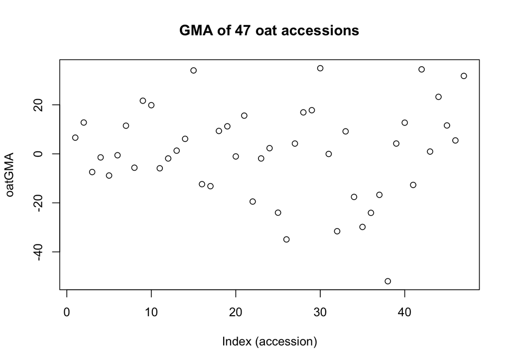

```r
# General Mixing Ability
# GMA_oat = Pr_oat + As_oat-on-pea
# overall effect of oat on the intercrop
oatGMA <- oatEff[,"PrEff"] + oatEff[,"AsEff"]
plot(oatGMA, xlab = "Index (accession)", main = "GMA of 47 oat accessions")
```

### Variance

```r
# Varience
bglr_model[["ETA"]][[5]][["Cov"]][["Omega"]] # variance
```

```
##           oatYield  peaYield
## oatYield 469.43965 -22.11237
## peaYield -22.11237  48.16176
```

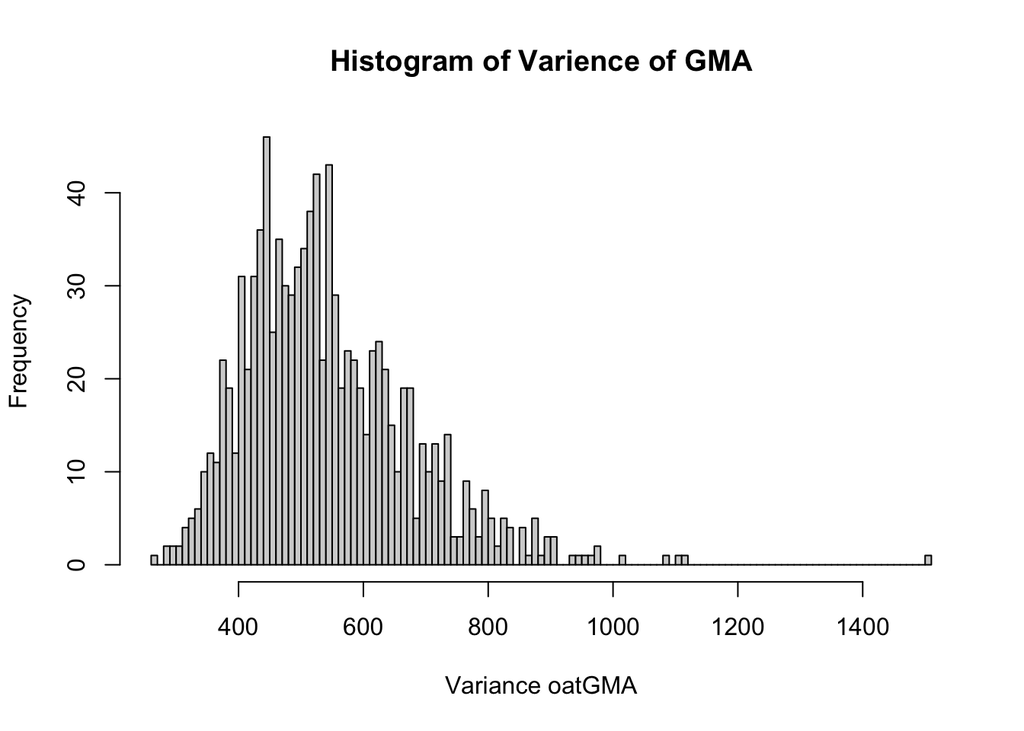

```r
# Omega_5.data holds the variances calculated by markov chain
  # In Omega_5.data:
    # VarGMAoat = VarPr + VarAs + 2Cov(Pr,As)
    # first = Pr, second = Cov, third = As

Omega_5 <- read_table(here("Omega_5.dat"), col_names = FALSE) # read in Omage5.dat

#Variance[GeneralMixingAbility Oat]
Omega_5$VarGMA <- Omega_5$X1 + Omega_5$X3 + 2*Omega_5$X2

hist_data <- hist(Omega_5$VarGMA, breaks = 100, xlab= "Variance oatGMA", main = "Histogram of Varience of GMA")
```

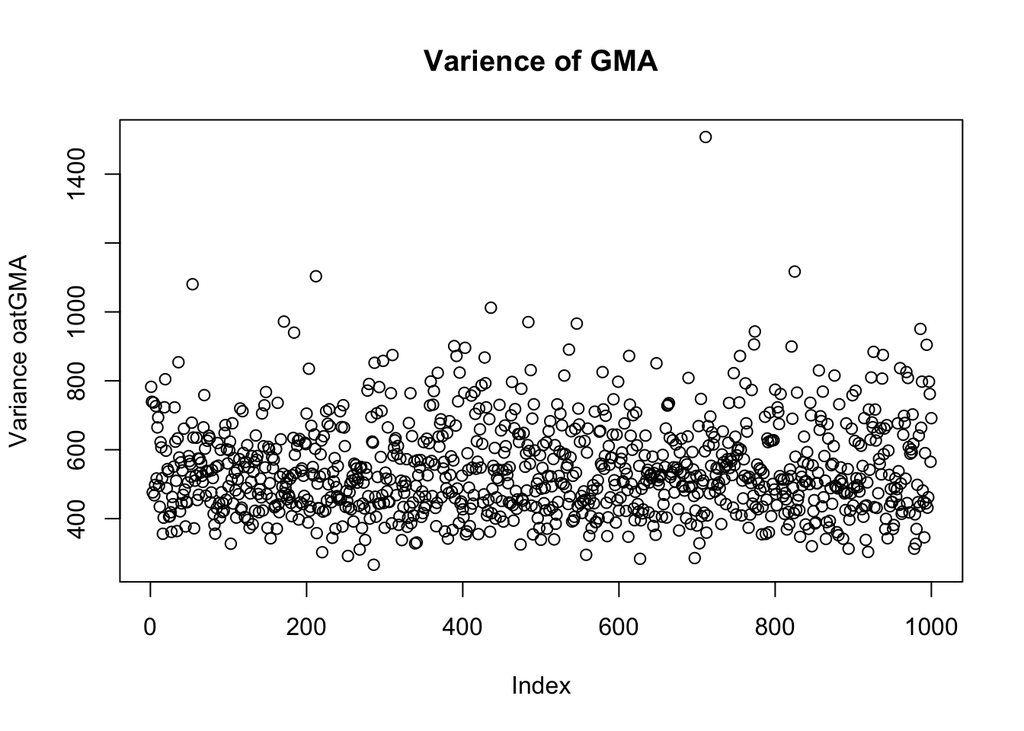

```r
plot(Omega_5$VarGMA, ylab= "Variance oatGMA", main = "Varience of GMA")
```

credible interval

range of the posterior distribution containing 95% of probable values. If interval does not overlap with zero, then their is evidence of true significant variability

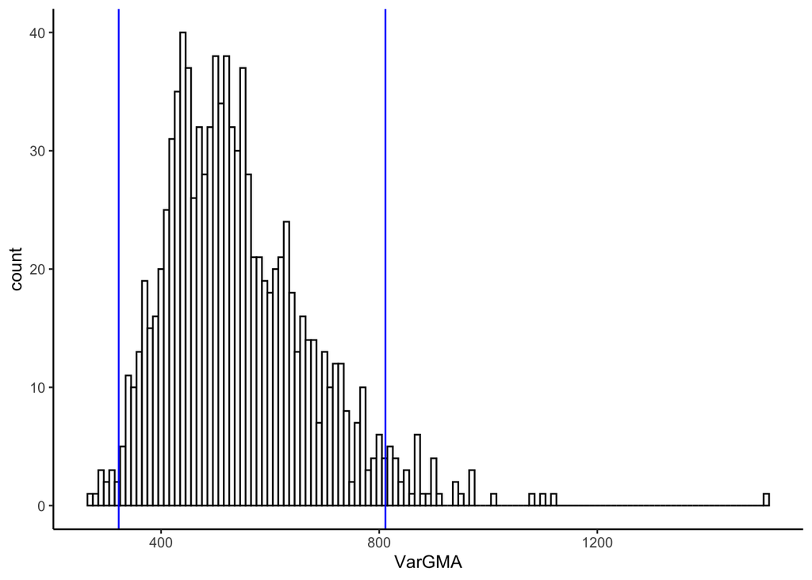

```r
# describe and summarise the uncertainty related to the unknown parameters you are trying to estimate
#credible interval is the range containing a particular percentage of probable values.
# 95% credible interval is the central portion of the posterior distribution that contains 95% of the values.

#compute credible interval using Highest Density Interval (HDI) (hdi())
# I chose to use HDI instead of the Equal-tailed Interval (ETI) (eti()) because we expect a skewed distribution and using an equal tail will place the interval so it has symmetric distribution which could lead to a interval that includes tail values that aren't 'credible' parameter values.
# want the smallest CI height (SPI) (Wikipedia says SPI is the same as HDI, but the ci package has separate options for them)

ci_hdi <- ci(Omega_5$VarGMA, method = "HDI") # default is 95%
ci_spi <- ci(Omega_5$VarGMA, method = "SPI") # default is 95%
#ci_hdi
#ci_spi
# they're very close in values

# Plot the distribution and add the limits of the two CIs

p <- ggplot(Omega_5, aes(x=VarGMA)) +
  geom_histogram(binwidth=10, color="black", fill="white")+
  theme_classic()+
  # SPI in blue
  geom_vline(xintercept = ci_spi$CI_low, color = "blue", linewidth = 0.5) +
  geom_vline(xintercept = ci_spi$CI_high, color = "blue", linewidth = 0.5)
p
```

Analysis for each of the variances and covariances (i.e., for “X1”, “X2”, and “X3”). For example, is X2, the covariance significantly negative? That is, does the credible interval overlap with 0?

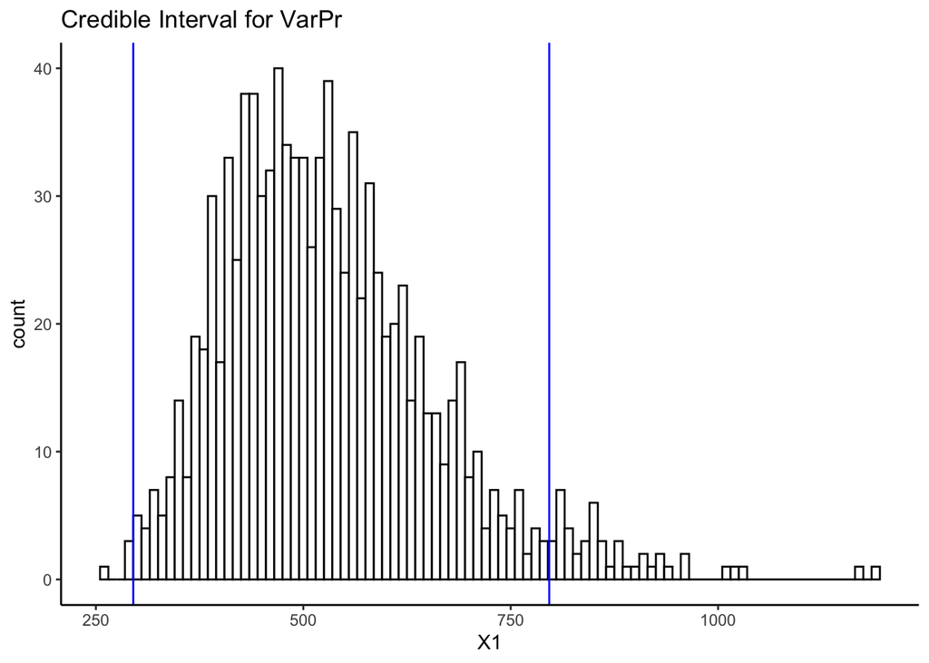

```r
ci_spi <- ci(Omega_5$X1, method = "SPI") # default is 95%
#ci_spi

p1 <- ggplot(Omega_5, aes(x=X1)) +
  geom_histogram(binwidth=10, color="black", fill="white")+
  theme_classic()+
  # SPI in blue
  geom_vline(xintercept = ci_spi$CI_low, color = "blue", linewidth = 0.5) +
  geom_vline(xintercept = ci_spi$CI_high, color = "blue", linewidth = 0.5)+
  ggtitle("Credible Interval for VarPr")
p1
```

```r
rm(ci_spi)
```

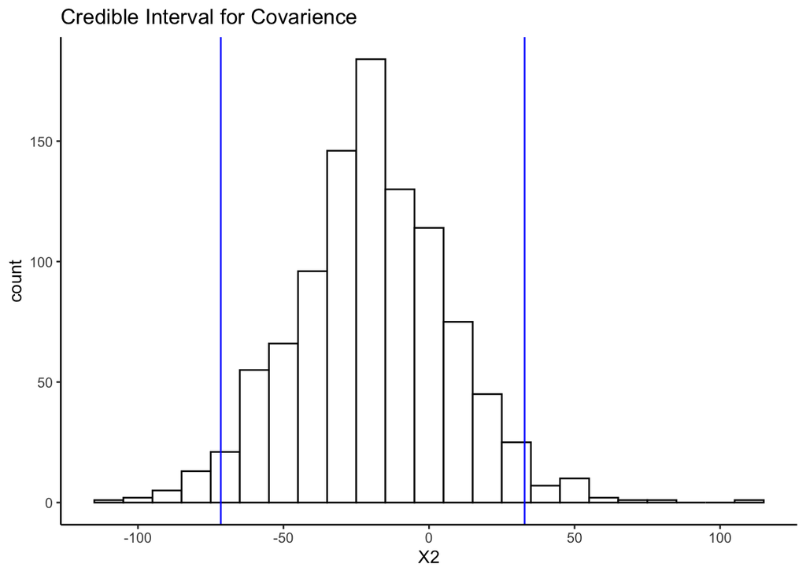

```r
ci_spi <- ci(Omega_5$X2, method = "SPI") # default is 95%
#ci_spi

p2 <- ggplot(Omega_5, aes(x=X2)) +
  geom_histogram(binwidth=10, color="black", fill="white")+
  theme_classic()+
  # SPI in blue
  geom_vline(xintercept = ci_spi$CI_low, color = "blue", linewidth = 0.5) +
  geom_vline(xintercept = ci_spi$CI_high, color = "blue", linewidth = 0.5)+
  ggtitle("Credible Interval for Covarience")
p2
```

```r
rm(ci_spi)
```

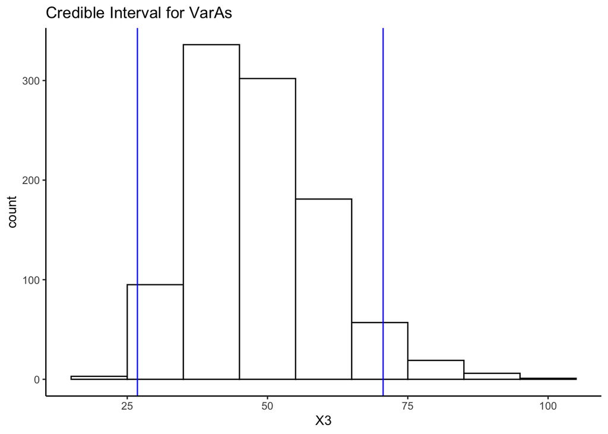

```r
ci_spi <- ci(Omega_5$X3, method = "SPI") # default is 95%
#ci_spi

p3 <- ggplot(Omega_5, aes(x=X3)) +
  geom_histogram(binwidth=10, color="black", fill="white")+
  theme_classic()+
  # SPI in blue
  geom_vline(xintercept = ci_spi$CI_low, color = "blue", linewidth = 0.5) +
  geom_vline(xintercept = ci_spi$CI_high, color = "blue", linewidth = 0.5)+
  ggtitle("Credible Interval for VarAs")
p3
```

```r
rm(ci_spi)
```